# ML-Types

Matthew Curcio

6/23/2019

Title: ML-Types

At the intersection between Statistics and Computer Science there is a portion outside of Bioinformtics. This intersecting area is where the field of Machine Learning or Predictive Analytics resides.

Despite its many names which include artificial intellgence and even intelligent machines, it boils down to use the use of mathematics and statistics coupled with data from large and small sources methodically extended in a way to classify or describe in useful ways for humans.

This boooklet will discuss supertwo of the most commonly studied facets of machine learning, Supervised and Unsupervised learning approaches.

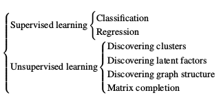

Two Types Of Machine Learning

[figure not shown]

##### Definitions:

1. **Supervised learning** is used whenever we want to predict a certain outcome from a given input, and we have examples of input/output pairs.
2. In **unsupervised learning**, the learning algorithm is just shown the input data and asked to extract knowledge from this data.[^1]

1. Supervised learning is the machine learning task of learning a function that maps an input to an output based on example input-output pairs.[^2] The algorithm determines a pattern from the input information and groups this with its title or classification. It may also produce regression lines or models that can be used for predictions.

### Supervised learning

**Input:**

1. (X, Y) is a **labeled pair**

Where:

- $\langle X \rangle ~~ is~ a~ matrix(m,n)~ \in \mathbb{R}^n$,
- $\langle Y \rangle ~~ is~ a~ matrix(m,1),~~~ label~y_i \in \{1, 2, 3, ...,C\}~~$

**Output:**

$f(x_i, x_j, ... ~| Y) = Classification(s)$

OR

$f(x_i, x_j, ... ~| Y) = Regression ~model(s)$

### Unsupervised learning

**Input:**

Where:

$\langle X \rangle ~~ is~ a~ matrix(m,n)~ \in \mathbb{R}^n$

**Output:**

[^1]: Introduction to Machine Learning with Python (2017), Andreas C. Müller & Sarah Guido, O’Reilly press, 2017
[^2]: Stuart J. Russell, Peter Norvig (2010) Artificial Intelligence: A Modern Approach, Third Edition, Prentice Hall